# By Course ID Test

Daniel Krasnov

2023-04-03

Having the university as the document and the concatenated course descriptions as the text tends to lead to noisy clusters. Therefore we opt to try training our model on a corpus where documents are the courses and their descriptions are the text. Our document number will then go from 9 to approximately 200.

```
## Package version: 3.2.4
## Unicode version: 13.0
## ICU version: 69.1
```

```
## Parallel computing: 16 of 16 threads used.
```

```
## See https://quanteda.io for tutorials and examples.
```

We begin by constructing our corpus object,

```r
data <- load("./data/RObjects/degree_corpus_by_course.RData")
colnames(degree_corpus_by_course) <- c("doc_id", "text")
degree_corpus_by_course <- degree_corpus_by_course[!duplicated(degree_corpus_by_course$doc_id),]
degree_corpus_by_course <- degree_corpus_by_course[degree_corpus_by_course$text != "",]
head(degree_corpus_by_course)
```

```
##                       doc_id
## 1   Computer Science 2210A/B
## 2   Computer Science 2211A/B
## 3 Computer Science 2212A/B/Y
## 4   Computer Science 2214A/B
## 5   Computer Science 3319A/B
## 6   Computer Science 3340A/B
##                                                                                                                                                                                                                                                                                                          …
## 1                                                                                                                                                                                                                       Lists, stacks, queues, priority queues, trees, graphs, and their associated algor…
## 2       An introduction to software tools and systems programming. Topics include: understanding how programs execute (compilation, linking and loading); an introduction to a complex operating system (UNIX); scripting languages; the C programming language; system calls; memory management; librari…
## 3                                                                                                                   A team project course that provides practical experience in the software engineering field. Introduction to the structure and unique characteristics of large software systems, and c…
## 4                           This course presents an introduction to the mathematical foundations of computer science, with an emphasis on mathematical reasoning, combinatorial analysis, discrete structures, applications and modeling, and algorithmic thinking. Topics include sets, functions, relat…
## 5 A study of relational databases. Theoretical concepts will be covered, including relational algebra and relational calculus. Commercially available database systems will be used to demonstrate concepts such as Structured-Query-Language (SQL), writing code to connect and query a database, query …
## 6                                                                                                                                                                                                                          Upper and lower time and space bounds; levels of intractability; graph algorit…
```

```r
ds <- DataframeSource(degree_corpus_by_course)
corpus <- Corpus(ds)
inspect(corpus[1])
```

```
## <<SimpleCorpus>>
## Metadata:  corpus specific: 1, document level (indexed): 0
## Content:  documents: 1
##
##                                                                                                                                                        Computer Science 2210A/B
## Lists, stacks, queues, priority queues, trees, graphs, and their associated algorithms; file structures; sorting, searching, and hashing techniques; time and space complexity.
```

We now clean our corpus. As previously explored using TF-IDF for term inclusion and stemming both lead to more difficult to interpret topics. Therefore we opt very basic cleaning. We also remove custom stopwords found in the previous attempts at modeling this dataset to be cumbersome for interpretation.

```r
# Remove punctuation
corpus <- tm_map(corpus, content_transformer(removePunctuation))
# Send everything to lower case
corpus <- tm_map(corpus, content_transformer(tolower))
# Remove stopwords
corpus <- tm_map(corpus,
                 content_transformer(removeWords),
                 stopwords("english"))
# Remove numbers
corpus <- tm_map(corpus, content_transformer(removeNumbers))

# Remove custom stop words
remove_words <-
  c("include","methods","topics","design","functions","emphasis","language","introduction","languages","performance","experience","course","techniques","variables","number","department","tools","fundamental","also","major","modern","issues","used","methods","using","case","architecture","covered","credit","basic","cosc","granted","use","solutions","will","students","fall","spring","important","one","considered","stacks","offers","types","may","held","former","honours","faculty","related","enter","review","enrolment","exercises","summer","need","offered","social","digital","terms","real","concepts","understanding","can","including","programs","program","recommended","examples","introduced","large","search","relations","key","etc","reasoning","intended","fws","general","restricted","version","two","comp","well","rich","intended","required","internet","recent","phys","sciences","covers","year","selected","renewal","explored","csch","principles","practice","development","studies","security","provides","advanced","instruction","discussed","processes","death","lower","high","crncr","taken","efficient","includes","core","retrieval","class","within","present","option","interested","together","session","week","new","order","tables","small","suitable","wide","without","good","introduces","assignments","current","thinking","completed","basics","essential","gain","effective","file","three","many","classes","extensive","tasks","work","meaningful","first","creating","elementary","image"
  )
corpus <- tm_map(corpus, function(x) {
  removeWords(x, remove_words)
})

# Remove whitespace
corpus <- tm_map(corpus, stripWhitespace)

inspect(corpus[1])
```

```
## <<SimpleCorpus>>
## Metadata:  corpus specific: 1, document level (indexed): 0
## Content:  documents: 1
##
##                                                                                                   Computer Science 2210A/B
## lists queues priority queues trees graphs associated algorithms structures sorting searching hashing time space complexity
```

Through experimentation it has been found that certain unigrams are better interpretable if we construct the most likely bigram the unigram is likely to participate in. This is found through collocations: terms that have a higher probability of appearing together than they do individually. High values of count, $\lambda$ and $z$ all point towards potentially good bigrams to include. We decide term inclusion ultimately by testing different models.

```r
# Inspecting BiGrams table

corpusq <- quanteda::corpus(corpus)

corpuz_tokzd <- quanteda::tokens(corpusq)

BiGrams <- corpuz_tokzd %>%
       quanteda::tokens_select(pattern = "^[A-Z]",
                               valuetype = "regex",
                               case_insensitive = TRUE,
                               padding = TRUE) %>%
       textstat_collocations(min_count = 8, tolower = FALSE,size=2)

head(BiGrams)
```

```
##              collocation count count_nested length   lambda        z
## 1              math math    31            0      2 7.510804 13.64619
## 2           data science    27            0      2 3.062254 11.75981
## 3            time series     9            0      2 5.838259 11.02856
## 4 differential equations    10            0      2 6.696623 10.83258
## 5           graph theory     9            0      2 5.202422 10.51883
## 6     hypothesis testing    10            0      2 8.155490 10.12133
```

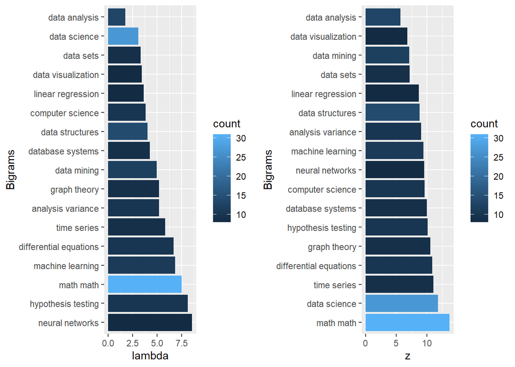

```r
# Plotting BiGrams
plot1 <- ggplot(BiGrams, aes(fill=count, y=lambda, x=reorder(collocation, -lambda))) +
    geom_bar(position="dodge", stat="identity") + coord_flip()+labs(x= "Bigrams", y = "lambda")

plot2 <- ggplot(BiGrams, aes(fill=count, y=z, x=reorder(collocation, -z))) +
    geom_bar(position="dodge", stat="identity") + coord_flip()+labs(x= "Bigrams", y = "z")

grid.arrange(plot1, plot2, ncol=2)
```

We will need a couple custom functions for combing terms and making bigrams,

```r
combineCols <- function(words, dtm, newColName){
  # Get indices of columns
idx <- which(colnames(dtm) %in% words)

# Convert sparse matrix dtm to normal matrix
dtm <- as.matrix(dtm)

# Combine columns
dtm[,c(idx[1])] <- rowSums(dtm[,c(idx)])

# Rename term
colnames(dtm)[idx[1]] <- newColName

if(length(words) == 2){
dtm <- dtm[,-idx[2]]
}else{
dtm <- dtm[,-idx[2:length(words)]]
}
# Convert back to DTM
dtm <- as.DocumentTermMatrix(as.simple_triplet_matrix(dtm),weighting = weightTf)

return(dtm)
}
```

```r
createBigram <- function(df,term1,term2,replacement){
  regex <- paste0(term1,"\\s+",term2)
  for (i in 1:nrow(df)) {
    row_text <- df[i, 2]
    df[i, 2] <- str_replace(row_text, regex, replacement)
  }
  return(df)
}
```

Now can add bigrams to our corpus,

```r
# Recreate data frame
cor <- as.list(corpus)
df <- cbind(data.frame("doc_id" = names(cor)),data.frame("text"=t(as.data.frame(cor))))

df <- createBigram(df,"data","science","data_science")
df <- createBigram(df,"data","structures","data_structures")
df <- createBigram(df,"data","analysis","data_analysis")
df <- createBigram(df,"data","mining","data_mining")
df <- createBigram(df,"machine","learning","machine_learning")
df <- createBigram(df,"computer","science","computer_science")
df <- createBigram(df,"time","series","time_series")
df <- createBigram(df,"database","systems","database_systems")
df <- createBigram(df,"data","visualization","data_visualization")
df <- createBigram(df,"neural","networks","neural_networks")
df <- createBigram(df,"graph","theory","graph_theory")
df <- createBigram(df,"differential","equations","differential_equations")
df <- createBigram(df,"big","data","big_data")
df <- createBigram(df,"hypothesis","testing","hypothesis_testing")
df <- createBigram(df,"linear","regression","linear_regression")
df <- createBigram(df,"regression","models","regression_models")
df <- createBigram(df,"data","sets","data_sets")
df <- createBigram(df,"text","data","text_data")
```

```r
ds2 <- DataframeSource(df)
corpus2 <- Corpus(ds2)

# Remove custom stop words
remove_words <-
  c("data","science")
corpus2 <- tm_map(corpus2, function(x) {
  removeWords(x, remove_words)
})

dtm <- DocumentTermMatrix(corpus2)
inspect(dtm)
```

```
## <<DocumentTermMatrix (documents: 233, terms: 1771)>>
## Non-/sparse entries: 4660/407983
## Sparsity           : 99%
## Maximal term length: 63
## Weighting          : term frequency (tf)
## Sample             :
##           Terms
## Docs       algorithms analysis applications linear math models programming
##   BUS 360W          0        0            0      0    0      0           0
##   BUS 439           0        1            0      0    0      0           0
##   CP321             0        3            0      0    0      0           0
##   CP421             3        0            0      0    0      1           0
##   CP423             0        0            1      0    0      0           0
##   CS 480            1        0            1      0    0      0           0
##   CSC494H1          0        0            2      0    0      0           0
##   MAT223H1          0        0            0      3    0      0           0
##   ST494             0        1            0      1    0      0           0
##   STAT 330          0        0            1      0    0      0           0
##           Terms
## Docs       software statistical systems
##   BUS 360W        0           0       0
##   BUS 439         0           0       0
##   CP321           0           0       0
##   CP421           0           0       3
##   CP423           0           0       0
##   CS 480          0           1       0
##   CSC494H1        0           0       0
##   MAT223H1        0           0       1
##   ST494           0           1       0
##   STAT 330        0           0       0
```

We also manually combine synonymous terms,

```r
dtm <-
  combineCols(c("math", "mathematics", "mathematically", "mathematical"),
              dtm,"mathematics")
dtm <- combineCols(c("stat", "statistics","statistical"), dtm,"statistics")
dtm <- combineCols(c("model","models","modeling"), dtm,"models")
dtm <- combineCols(c("database","databases"), dtm,"database")
```

Now we can move onto discovering optimal $K$ values.

```r
# Find number of topics
result <- FindTopicsNumber(
  dtm,
  topics = seq(from = 2, to = 20, by = 1),
  metrics = c("Griffiths2004", "CaoJuan2009", "Arun2010", "Deveaud2014"),
  method = "Gibbs",
  control = list(seed = 77),
  mc.cores = 2L,
)
# Plot metrics
suppressWarnings(FindTopicsNumber_plot(result))
```

[figure not shown]

```r
set.seed(87460945)

# Calculate folds
idxs <- sample(seq_len(9))
folds <- split(idxs, rep(1:3, each = 3, length.out = 9))

# Define number of topics
topics <- seq(2, 50, 1)

# Create data frame for storing results
results <- data.frame()

# Perform cross validation
for (k in topics) {
  scores <- c()
  for (i in 1:3) {
    test_idx <- folds[[i]]
    train_idx <- setdiff(unlist(folds, use.names = FALSE), test_idx)

    test <- dtm[test_idx, ]
    train <- dtm[train_idx, ]

    LDA.out <- LDA(dtm, k, method = "Gibbs")
    p <- perplexity(LDA.out, newdata = test)
    scores <- c(scores, p)
  }
  temp <- data.frame("K" = k, "Perplexity" = mean(scores))
  results <- rbind(results, temp)
}

# Plot Perplexity vs. K
ggplot(results, aes(x=K, y=Perplexity)) + geom_line() + ggtitle("Perplexity vs. Number of Topics K")+
  theme(plot.title = element_text(hjust = 0.5))
```

[figure not shown]

```r
# Retrieving K for minimum Perplexity
results[which.min(results$Perplexity),"K"]
```

```
## [1] 14
```

Some optimal topic numbers are 3, 5, 8, 9, 12, 14, 15, 20, 25. Now we can visualize them with LDAvis noting that we set $\lambda=0.6$.

```r
# Fit largest model
lda.out <- LDA(dtm, 3, method = "Gibbs",control = list(seed = 87460945))

# Find required quantities
phi <- posterior(lda.out)$terms %>% as.matrix
theta <- posterior(lda.out)$topics %>% as.matrix
vocab <- colnames(phi)
doc_length <- vector()
for (i in 1:length(corpus)) {
  temp <- paste(corpus[[i]]$content, collapse = ' ')
  doc_length <-
    c(doc_length, stri_count(temp, regex = '\\S+'))
}
temp_frequency <- as.matrix(dtm)
freq_matrix <- data.frame(ST = colnames(temp_frequency),
                          Freq = colSums(temp_frequency))

# Convert to json
json_lda <- LDAvis::createJSON(
  phi = phi,
  theta = theta,
  vocab = vocab,
  doc.length = doc_length,
  term.frequency = freq_matrix$Freq
)

# Open server for visualization
# serVis(json_lda, out.dir = "./TestVis/K_3", open.browser = FALSE)
# serVis(json_lda, open.browser = TRUE)
```

View the visualization [here](https://danyulll.github.io/vis_k_3/).

As we might expect the overarching topics of any Data Science curriculum are programming, statistics, and mathematics. Importantly, models actually beats out statistics indicating that data scientists are primarily concerned with modelling as opposed to inference or estimation.

```r
# Fit largest model
lda.out <- LDA(dtm, 5, method = "Gibbs",control = list(seed = 87460945))

# Find required quantities
phi <- posterior(lda.out)$terms %>% as.matrix
theta <- posterior(lda.out)$topics %>% as.matrix
vocab <- colnames(phi)
doc_length <- vector()
for (i in 1:length(corpus)) {
  temp <- paste(corpus[[i]]$content, collapse = ' ')
  doc_length <-
    c(doc_length, stri_count(temp, regex = '\\S+'))
}
temp_frequency <- as.matrix(dtm)
freq_matrix <- data.frame(ST = colnames(temp_frequency),
                          Freq = colSums(temp_frequency))

# Convert to json
json_lda <- LDAvis::createJSON(
  phi = phi,
  theta = theta,
  vocab = vocab,
  doc.length = doc_length,
  term.frequency = freq_matrix$Freq
)

# Open server for visualization
# serVis(json_lda, out.dir = "./TestVis/K_5", open.browser = FALSE)
# serVis(json_lda, open.browser = TRUE)
```

View the visualization [here](https://danyulll.github.io/vis_k_5/).

Now topics begin to become more nuanced: * Topic 1: statistics comes to the top with applications, random, theory, probability, estimation, and distributions trailing behind. Clearly a statistics topic. * Topic 2: software, database, and systems come to the top of this topic. Databases are an important part of any data scientist’s job and it makes sense this would be put into its own topic- its quite distinct from any of the others. * Topic 3: models, analysis, learning, regression, clustering, classification, and machine_learning. Very clearly a machine learning topic. * Topic 4: mathematics is by in large the most relevant term. This coupled with words such as calculus, equations, linear, integration shows this is a mathematics topic. * Topic 5: programming, algorithms, computer, objectorientated, this is likely the computer science and programming aspect of any data science program.

```r
# Fit largest model
lda.out <- LDA(dtm, 8, method = "Gibbs",control = list(seed = 87460945))

# Find required quantities
phi <- posterior(lda.out)$terms %>% as.matrix
theta <- posterior(lda.out)$topics %>% as.matrix
vocab <- colnames(phi)
doc_length <- vector()
for (i in 1:length(corpus)) {
  temp <- paste(corpus[[i]]$content, collapse = ' ')
  doc_length <-
    c(doc_length, stri_count(temp, regex = '\\S+'))
}
temp_frequency <- as.matrix(dtm)
freq_matrix <- data.frame(ST = colnames(temp_frequency),
                          Freq = colSums(temp_frequency))

# Convert to json
json_lda <- LDAvis::createJSON(
  phi = phi,
  theta = theta,
  vocab = vocab,
  doc.length = doc_length,
  term.frequency = freq_matrix$Freq
)

# Open server for visualization
# serVis(json_lda, out.dir = "./TestVis/K_8", open.browser = FALSE)
# serVis(json_lda, open.browser = TRUE)
```

View the visualization [here](https://danyulll.github.io/vis_k_8/).

For the sake of brevity I will simply list what I consider to be the most likely topics from here on out. Note asterisks indicate noisey topics I am unsure of.

- Topic 1: statistics
- Topic 2: machine learning
- Topic 3: business
- Topic 4: mathematics
- Topic 5: data analysis/inference
- Topic 6: databases
- Topic 7: computer science
- Topic 8: linear algebra

```r
# Fit largest model
lda.out <- LDA(dtm, 9, method = "Gibbs",control = list(seed = 87460945))

# Find required quantities
phi <- posterior(lda.out)$terms %>% as.matrix
theta <- posterior(lda.out)$topics %>% as.matrix
vocab <- colnames(phi)
doc_length <- vector()
for (i in 1:length(corpus)) {
  temp <- paste(corpus[[i]]$content, collapse = ' ')
  doc_length <-
    c(doc_length, stri_count(temp, regex = '\\S+'))
}
temp_frequency <- as.matrix(dtm)
freq_matrix <- data.frame(ST = colnames(temp_frequency),
                          Freq = colSums(temp_frequency))

# Convert to json
json_lda <- LDAvis::createJSON(
  phi = phi,
  theta = theta,
  vocab = vocab,
  doc.length = doc_length,
  term.frequency = freq_matrix$Freq
)

# Open server for visualization
# serVis(json_lda, out.dir = "./TestVis/K_9", open.browser = FALSE)
# serVis(json_lda, open.browser = TRUE)
```

View the visualization [here](https://danyulll.github.io/vis_k_9/).

- Topic 1: probability theory
- Topic 2: machine learning
- Topic 3: business analytics/marketing
- Topic 4: mathematics
- Topic 5: databases
- Topic 6: data analysis*
- Topic 7: computer science
- Topic 8: business applications*
- Topic 9: communication

```r
# Fit largest model
lda.out <- LDA(dtm, 12, method = "Gibbs",control = list(seed = 87460945))

# Find required quantities
phi <- posterior(lda.out)$terms %>% as.matrix
theta <- posterior(lda.out)$topics %>% as.matrix
vocab <- colnames(phi)
doc_length <- vector()
for (i in 1:length(corpus)) {
  temp <- paste(corpus[[i]]$content, collapse = ' ')
  doc_length <-
    c(doc_length, stri_count(temp, regex = '\\S+'))
}
temp_frequency <- as.matrix(dtm)
freq_matrix <- data.frame(ST = colnames(temp_frequency),
                          Freq = colSums(temp_frequency))

# Convert to json
json_lda <- LDAvis::createJSON(
  phi = phi,
  theta = theta,
  vocab = vocab,
  doc.length = doc_length,
  term.frequency = freq_matrix$Freq
)

# Open server for visualization
# serVis(json_lda, out.dir = "./TestVis/K_12", open.browser = FALSE)
# serVis(json_lda, open.browser = TRUE)
```

View the visualization [here](https://danyulll.github.io/vis_k_12/).

- Topic 1: machine learning
- Topic 2: probability theory
- Topic 3: statistics/inference
- Topic 4: communication
- Topic 5: mathematics
- Topic 6: linear algebra
- Topic 7: databases
- Topic 8: algorithms, data structures, computer science
- Topic 9: programming
- Topic 10: applications*
- Topic 11: data analysis*
- Topic 12: proofs

```r
# Fit largest model
lda.out <- LDA(dtm, 14, method = "Gibbs",control = list(seed = 87460945))

# Find required quantities
phi <- posterior(lda.out)$terms %>% as.matrix
theta <- posterior(lda.out)$topics %>% as.matrix
vocab <- colnames(phi)
doc_length <- vector()
for (i in 1:length(corpus)) {
  temp <- paste(corpus[[i]]$content, collapse = ' ')
  doc_length <-
    c(doc_length, stri_count(temp, regex = '\\S+'))
}
temp_frequency <- as.matrix(dtm)
freq_matrix <- data.frame(ST = colnames(temp_frequency),
                          Freq = colSums(temp_frequency))

# Convert to json
json_lda <- LDAvis::createJSON(
  phi = phi,
  theta = theta,
  vocab = vocab,
  doc.length = doc_length,
  term.frequency = freq_matrix$Freq
)

# Open server for visualization
# serVis(json_lda, out.dir = "./TestVis/K_14", open.browser = FALSE)
# serVis(json_lda, open.browser = TRUE)
```

View the visualization [here](https://danyulll.github.io/vis_k_14/).

- Topic 1: machine learning
- Topic 2: statistics
- Topic 3: communication
- Topic 4: mathematics
- Topic 5: databases
- Topic 6: linear algebra
- Topic 7: research*
- Topic 8: data analysis
- Topic 9: ?
- Topic 10: programming
- Topic 11: data_structures
- Topic 12: inference
- Topic 13: programming*
- Topic 14: applications*

```r
# Fit largest model
lda.out <- LDA(dtm, 15, method = "Gibbs",control = list(seed = 87460945))

# Find required quantities
phi <- posterior(lda.out)$terms %>% as.matrix
theta <- posterior(lda.out)$topics %>% as.matrix
vocab <- colnames(phi)
doc_length <- vector()
for (i in 1:length(corpus)) {
  temp <- paste(corpus[[i]]$content, collapse = ' ')
  doc_length <-
    c(doc_length, stri_count(temp, regex = '\\S+'))
}
temp_frequency <- as.matrix(dtm)
freq_matrix <- data.frame(ST = colnames(temp_frequency),
                          Freq = colSums(temp_frequency))

# Convert to json
json_lda <- LDAvis::createJSON(
  phi = phi,
  theta = theta,
  vocab = vocab,
  doc.length = doc_length,
  term.frequency = freq_matrix$Freq
)

# Open server for visualization
# serVis(json_lda, out.dir = "./TestVis/K_15", open.browser = FALSE)
# serVis(json_lda, open.browser = TRUE)
```

View the visualization [here](https://danyulll.github.io/vis_k_15/).

- Topic 1: probability theory
- Topic 2: machine learning
- Topic 3: business
- Topic 4: communication
- Topic 5: statistics/inference
- Topic 6: mathematics
- Topic 7: calculus
- Topic 8: databases
- Topic 9: programming
- Topic 10: algorithms/data structures
- Topic 11: linear regression or linear algebra
- Topic 12: modelling
- Topic 13: statistics*
- Topic 14: experiment design
- Topic 15: analytics*

```r
# Fit largest model
lda.out <- LDA(dtm, 20, method = "Gibbs",control = list(seed = 87460945))

# Find required quantities
phi <- posterior(lda.out)$terms %>% as.matrix
theta <- posterior(lda.out)$topics %>% as.matrix
vocab <- colnames(phi)
doc_length <- vector()
for (i in 1:length(corpus)) {
  temp <- paste(corpus[[i]]$content, collapse = ' ')
  doc_length <-
    c(doc_length, stri_count(temp, regex = '\\S+'))
}
temp_frequency <- as.matrix(dtm)
freq_matrix <- data.frame(ST = colnames(temp_frequency),
                          Freq = colSums(temp_frequency))

# Convert to json
json_lda <- LDAvis::createJSON(
  phi = phi,
  theta = theta,
  vocab = vocab,
  doc.length = doc_length,
  term.frequency = freq_matrix$Freq
)

# Open server for visualization
# serVis(json_lda, out.dir = "./TestVis/K_20", open.browser = FALSE)
# serVis(json_lda, open.browser = TRUE)
```

View the visualization [here](https://danyulll.github.io/vis_k_20/).

- Topic 1: probability theory
- Topic 2: machine learning
- Topic 3: data mining
- Topic 4: mathematics
- Topic 5: databases
- Topic 6: calculus
- Topic 7: statistics/inference
- Topic 8: algorithms/data structures
- Topic 9: communication
- Topic 10: projects*
- Topic 11: data analysis/ hypothesis testing
- Topic 12: linear algebra
- Topic 13: experiment design
- Topic 14: programming
- Topic 15: ?
- Topic 16: ?
- Topic 17: object orientated programming*
- Topic 18: regression
- Topic 19: ?
- Topic 20: statistics

```r
# Fit largest model
lda.out <- LDA(dtm, 25, method = "Gibbs",control = list(seed = 87460945))

# Find required quantities
phi <- posterior(lda.out)$terms %>% as.matrix
theta <- posterior(lda.out)$topics %>% as.matrix
vocab <- colnames(phi)
doc_length <- vector()
for (i in 1:length(corpus)) {
  temp <- paste(corpus[[i]]$content, collapse = ' ')
  doc_length <-
    c(doc_length, stri_count(temp, regex = '\\S+'))
}
temp_frequency <- as.matrix(dtm)
freq_matrix <- data.frame(ST = colnames(temp_frequency),
                          Freq = colSums(temp_frequency))

# Convert to json
json_lda <- LDAvis::createJSON(
  phi = phi,
  theta = theta,
  vocab = vocab,
  doc.length = doc_length,
  term.frequency = freq_matrix$Freq
)

# Open server for visualization
# serVis(json_lda, out.dir = "./TestVis/K_25", open.browser = FALSE)
# serVis(json_lda, open.browser = TRUE)
```

View the visualization [here](https://danyulll.github.io/vis_k_25/).

- Topic 1: probability theory
- Topic 2: calculus
- Topic 3: modelling*
- Topic 4: machine learning
- Topic 5: linear algebra
- Topic 6: databases
- Topic 7: statistics
- Topic 8: algorithms
- Topic 9: mathematics
- Topic 10: programming
- Topic 11: inference
- Topic 12: analytics*
- Topic 13: experiment design
- Topic 14: writing*
- Topic 15: projects*
- Topic 16: business
- Topic 17: computational methods*
- Topic 18: text data*
- Topic 19: data mining
- Topic 20: ?
- Topic 21: data visualization*
- Topic 22: regression
- Topic 23: time series
- Topic 24: data analysis*
- Topic 25: research/marketing